# Ingreso en Álvaro Obregón

Equipo 6

```r
suppressPackageStartupMessages({
library(tidyverse)
library(dplyr)
library(tidyr)
library(matlib)
library(ggplot2)
library(olsrr)
library(GGally)
library(MASS)
library(lmtest)
library(orcutt)
library(HoRM)
library(normtest)
library(car)
library(nlme)
})
```

Lectura de la base de datos

```r
  #datos <- read.csv("BaseDatosEA2.csv")
  #Cambiamos la base porque nos marcaba error en la linea 43, esta base ya esta limpia, solo estan los datos de Alvaro Obregon y las variables que
  #pensamos utilizar en el modelo
  datos <- read.csv("BaseDatos2.csv")
  head(datos)
```

```
##   est_socio sexo_jefe edad_jefe educa_jefe tot_integ perc_ocupa  ing_cor
## 1         2         2        87          1         3          0 21155.35
## 2         2         2        33          4         3          3 27162.08
## 3         2         2        39          7         3          1 33281.37
## 4         2         2        62          4         8          3 60396.54
## 5         2         1        33          8         6          1 23121.86
## 6         3         2        71          6         2          0 42153.56
##   gasto_mon erogac_tot
## 1  14448.31       0.00
## 2  18980.33    6603.26
## 3  21509.02       0.00
## 4  41009.29       0.00
## 5  29813.11       0.00
## 6  20792.53   10360.09
```

Número de renglones y nombre de las columnas

```r
  nrow(datos)
```

```
## [1] 144
```

```r
  names(datos)
```

```
## [1] "est_socio"  "sexo_jefe"  "edad_jefe"  "educa_jefe" "tot_integ"
## [6] "perc_ocupa" "ing_cor"    "gasto_mon"  "erogac_tot"
```

Optimizar la elección de variables para nuestro modelo de regresión lineal múltiple.

```r
#Regresión múltiple lineal entre todas las combinaciones posibles de 8 variables
modeloCDMX <- lm(datos$ing_cor ~ est_socio + perc_ocupa + erogac_tot + gasto_mon + sexo_jefe + educa_jefe + tot_integ + edad_jefe, data = datos)
summary(modeloCDMX)
```

```
##
## Call:
## lm(formula = datos$ing_cor ~ est_socio + perc_ocupa + erogac_tot +
##     gasto_mon + sexo_jefe + educa_jefe + tot_integ + edad_jefe,
##     data = datos)
##
## Residuals:
##    Min     1Q Median     3Q    Max
## -95237 -20078  -5850  12957 344306
##
## Coefficients:
##               Estimate Std. Error t value Pr(>|t|)
## (Intercept) -6.978e+04  2.849e+04  -2.449 0.015591 *
## est_socio    7.335e+03  5.867e+03   1.250 0.213420
## perc_ocupa   5.953e+03  4.743e+03   1.255 0.211647
## erogac_tot   6.263e-01  2.308e-01   2.714 0.007524 **
## gasto_mon    1.198e+00  1.203e-01   9.952  < 2e-16 ***
## sexo_jefe   -1.507e+04  8.253e+03  -1.826 0.070052 .
## educa_jefe   5.524e+03  1.794e+03   3.079 0.002517 **
## tot_integ   -2.900e+03  2.985e+03  -0.972 0.332964
## edad_jefe    1.068e+03  2.827e+02   3.777 0.000237 ***
## ---
## Signif. codes:  0 '***' 0.001 '**' 0.01 '*' 0.05 '.' 0.1 ' ' 1
##
## Residual standard error: 44840 on 135 degrees of freedom
## Multiple R-squared:  0.768,  Adjusted R-squared:  0.7543
## F-statistic: 55.87 on 8 and 135 DF,  p-value: < 2.2e-16
```

```r
#Optimiza y muestra las mejores 8 regresiones por número de variables a tomar en cuenta
ols_step_best_subset(modeloCDMX)
```

```
##                                      Best Subsets Regression
## -------------------------------------------------------------------------------------------------
## Model Index    Predictors
## -------------------------------------------------------------------------------------------------
##      1         gasto_mon
##      2         est_socio gasto_mon
##      3         gasto_mon educa_jefe edad_jefe
##      4         erogac_tot gasto_mon educa_jefe edad_jefe
##      5         erogac_tot gasto_mon sexo_jefe educa_jefe edad_jefe
##      6         est_socio erogac_tot gasto_mon sexo_jefe educa_jefe edad_jefe
##      7         est_socio perc_ocupa erogac_tot gasto_mon sexo_jefe educa_jefe edad_jefe
##      8         est_socio perc_ocupa erogac_tot gasto_mon sexo_jefe educa_jefe tot_integ edad_jefe
## -------------------------------------------------------------------------------------------------
##
##                                                                   Subsets Regression Summary
## --------------------------------------------------------------------------------------------------------------------------------------------------------------
##                        Adj.        Pred
## Model    R-Square    R-Square    R-Square     C(p)         AIC         SBIC          SBC             MSEP                 FPE               HSP          APC
## --------------------------------------------------------------------------------------------------------------------------------------------------------------
##   1        0.7108      0.7087      0.6979    28.3124    3521.8392    3112.5654    3530.7486    343163802395.2068    2416177016.0914    16901267.3816    0.2974
##   2        0.7245      0.7205      0.7056    22.3575    3516.8673    3107.5802    3528.7466    329280367745.1343    2334187555.1359    16332507.6744    0.2873
##   3        0.7425      0.7370      0.7194    13.8556    3509.1137    3100.1437    3523.9627    309929377075.3575    2211845953.3734    15482491.6044    0.2722
##   4        0.7576      0.7506      0.7355     7.0676    3502.4113    3093.9640    3520.2302    293868244790.1472    2111285023.2442    14785771.9749    0.2598
##   5        0.7615      0.7529      0.7378     6.7948    3502.0724    3093.8653    3522.8610    291244069248.3284    2106364290.7607    14759924.9572    0.2592
##   6        0.7650      0.7547      0.7378     6.7818    3501.9686    3094.0475    3525.7271    289130509881.7109    2104906765.3601    14759766.9562    0.2591
##   7        0.7664      0.7544       0.735     7.9441    3503.0840    3095.3708    3529.8123    289488355582.9904    2121354261.2644    14886696.5703    0.2611
##   8        0.7680      0.7543      0.7334     9.0000    3504.0804    3096.6172    3533.7786    289623290079.7589    2136188618.4287    15003958.6896    0.2629
## --------------------------------------------------------------------------------------------------------------------------------------------------------------
## AIC: Akaike Information Criteria
##  SBIC: Sawa's Bayesian Information Criteria
##  SBC: Schwarz Bayesian Criteria
##  MSEP: Estimated error of prediction, assuming multivariate normality
##  FPE: Final Prediction Error
##  HSP: Hocking's Sp
##  APC: Amemiya Prediction Criteria
```

Inicialmente elegimos el modelo con las 6 variables puesto que $R^2=0.7650$

Analizando el modelo individual, obtendremos los valores estimados $b_0, .., b_6$ para cada variable explicativa. Así también un análisis general de los residuos.

```r
modeloCDMX <- lm(datos$ing_cor ~ edad_jefe + erogac_tot + gasto_mon + sexo_jefe + educa_jefe + est_socio, datos)
summary(modeloCDMX)
```

```
##
## Call:
## lm(formula = datos$ing_cor ~ edad_jefe + erogac_tot + gasto_mon +
##     sexo_jefe + educa_jefe + est_socio, data = datos)
##
## Residuals:
##    Min     1Q Median     3Q    Max
## -96389 -20431  -6168  13476 345258
##
## Coefficients:
##               Estimate Std. Error t value Pr(>|t|)
## (Intercept) -7.353e+04  2.541e+04  -2.894 0.004425 **
## edad_jefe    1.003e+03  2.779e+02   3.609 0.000429 ***
## erogac_tot   6.446e-01  2.298e-01   2.805 0.005767 **
## gasto_mon    1.208e+00  1.145e-01  10.548  < 2e-16 ***
## sexo_jefe   -1.219e+04  7.837e+03  -1.556 0.122104
## educa_jefe   5.455e+03  1.781e+03   3.063 0.002642 **
## est_socio    8.209e+03  5.781e+03   1.420 0.157900
## ---
## Signif. codes:  0 '***' 0.001 '**' 0.01 '*' 0.05 '.' 0.1 ' ' 1
##
## Residual standard error: 44800 on 137 degrees of freedom
## Multiple R-squared:  0.765,  Adjusted R-squared:  0.7547
## F-statistic: 74.31 on 6 and 137 DF,  p-value: < 2.2e-16
```

Como estrato socioeconómico es el p-value más grande, ahora corremos la regresión omitiendo esa variable y volvemos a buscar el p-value más grande

```r
  modeloCDMX2 <- lm(datos$ing_cor ~ edad_jefe + erogac_tot + gasto_mon + sexo_jefe + educa_jefe, datos)
  summary(modeloCDMX2)
```

```
##
## Call:
## lm(formula = datos$ing_cor ~ edad_jefe + erogac_tot + gasto_mon +
##     sexo_jefe + educa_jefe, data = datos)
##
## Residuals:
##    Min     1Q Median     3Q    Max
## -94041 -22861  -3969  13763 350480
##
## Coefficients:
##               Estimate Std. Error t value Pr(>|t|)
## (Intercept) -5.963e+04  2.353e+04  -2.534 0.012392 *
## edad_jefe    1.070e+03  2.749e+02   3.892 0.000154 ***
## erogac_tot   6.942e-01  2.280e-01   3.045 0.002789 **
## gasto_mon    1.227e+00  1.141e-01  10.753  < 2e-16 ***
## sexo_jefe   -1.182e+04  7.862e+03  -1.503 0.135057
## educa_jefe   6.114e+03  1.726e+03   3.542 0.000542 ***
## ---
## Signif. codes:  0 '***' 0.001 '**' 0.01 '*' 0.05 '.' 0.1 ' ' 1
##
## Residual standard error: 44970 on 138 degrees of freedom
## Multiple R-squared:  0.7615, Adjusted R-squared:  0.7529
## F-statistic: 88.12 on 5 and 138 DF,  p-value: < 2.2e-16
```

Veamos que ahora con el modelo de regresión lineal solo con las 4 variables: edad, erogaciones totales, gasto y años escolarizados ya todas son significativas. Por lo tanto, solo vamos a considerar a $Y = \beta_0 + \beta_1 X_{edad} + \beta_2 X_{erogac} + \beta_3 X_{gasto} + \beta_4 X_{añosEsc}$

```r
    mejoraCDMX1 <- lm(datos$ing_cor ~ edad_jefe  +erogac_tot + gasto_mon  + educa_jefe, datos)
    summary(mejoraCDMX1)
```

```
##
## Call:
## lm(formula = datos$ing_cor ~ edad_jefe + erogac_tot + gasto_mon +
##     educa_jefe, data = datos)
##
## Residuals:
##     Min      1Q  Median      3Q     Max
## -101422  -21490   -3422   12654  354820
##
## Coefficients:
##               Estimate Std. Error t value Pr(>|t|)
## (Intercept) -7.445e+04  2.146e+04  -3.469 0.000696 ***
## edad_jefe    9.984e+02  2.720e+02   3.671 0.000344 ***
## erogac_tot   6.726e-01  2.286e-01   2.943 0.003814 **
## gasto_mon    1.228e+00  1.146e-01  10.716  < 2e-16 ***
## educa_jefe   6.390e+03  1.724e+03   3.706 0.000303 ***
## ---
## Signif. codes:  0 '***' 0.001 '**' 0.01 '*' 0.05 '.' 0.1 ' ' 1
##
## Residual standard error: 45170 on 139 degrees of freedom
## Multiple R-squared:  0.7576, Adjusted R-squared:  0.7506
## F-statistic: 108.6 on 4 and 139 DF,  p-value: < 2.2e-16
```

Renombramos las variables del sexo 1: hombre y 0: mujer

```r
  datos$sexo_jefe <- factor(datos$sexo_jefe)
  levels(datos$sexo_jefe) <- c("Hombre","Mujer")
```

Renombramos las variables del estrato socioeconómico 1: bajo, 2: medio bajo, 3: medio alto, 4: alto

```r
  datos$est_socio<- factor(datos$est_socio)
  levels(datos$est_socio) <- c("Medio bajo", "Medio alto", "Alto")
```

Graficas de las variables independientes elegidas vs ingreso

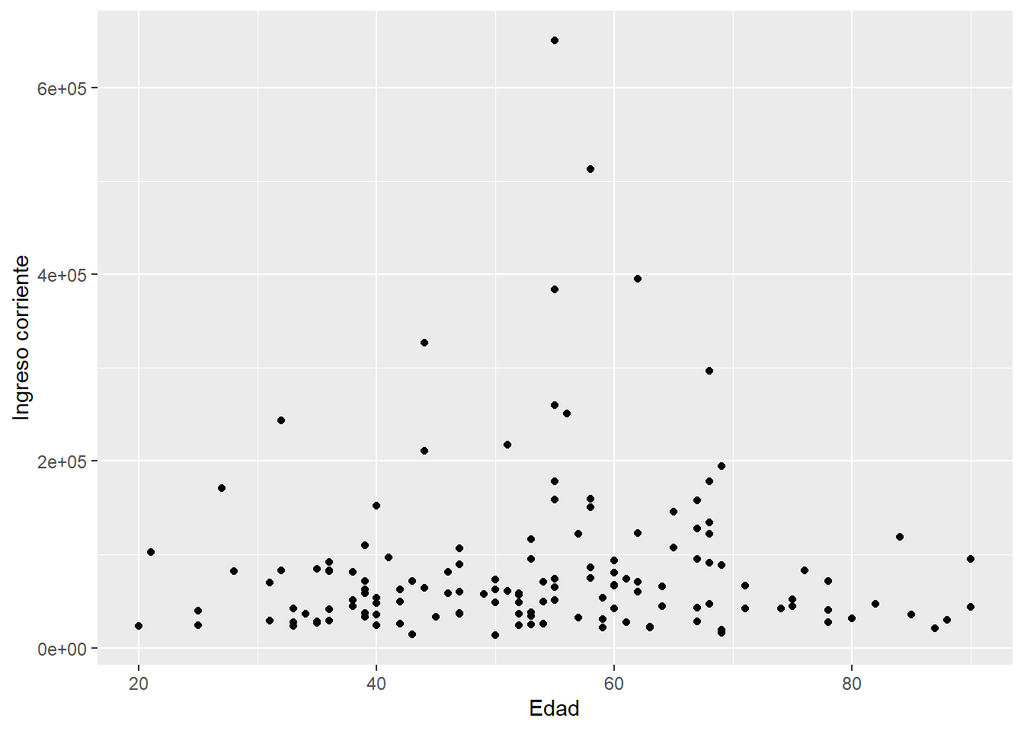

```r
ggplot(datos,aes(edad_jefe, ing_cor))+geom_point() +labs(y= "Ingreso corriente", x = "Edad")
```

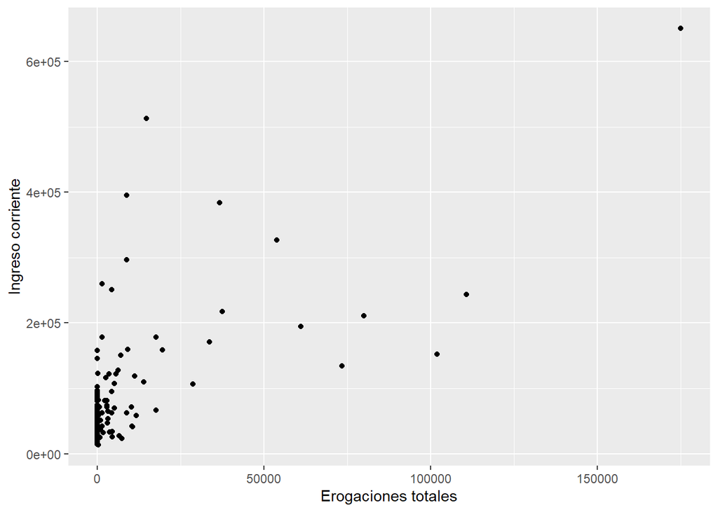

```r
ggplot(datos,aes(erogac_tot, ing_cor))+geom_point() +labs(y= "Ingreso corriente", x = "Erogaciones totales")
```

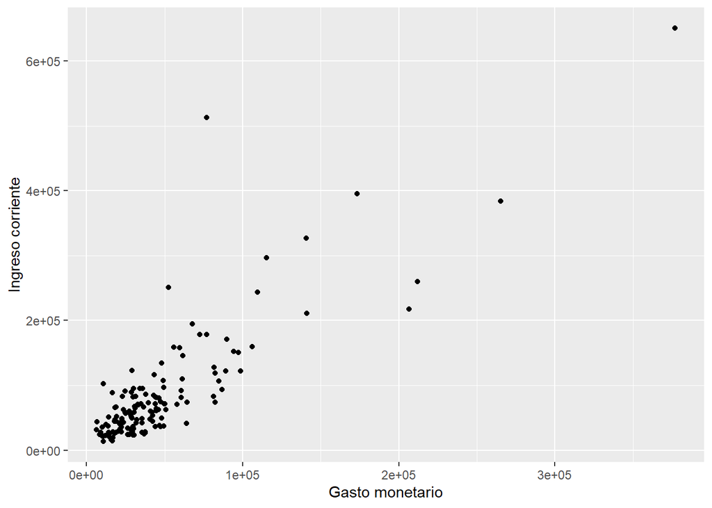

```r
ggplot(datos,aes(gasto_mon, ing_cor))+geom_point() +labs(y= "Ingreso corriente", x = "Gasto monetario")
```

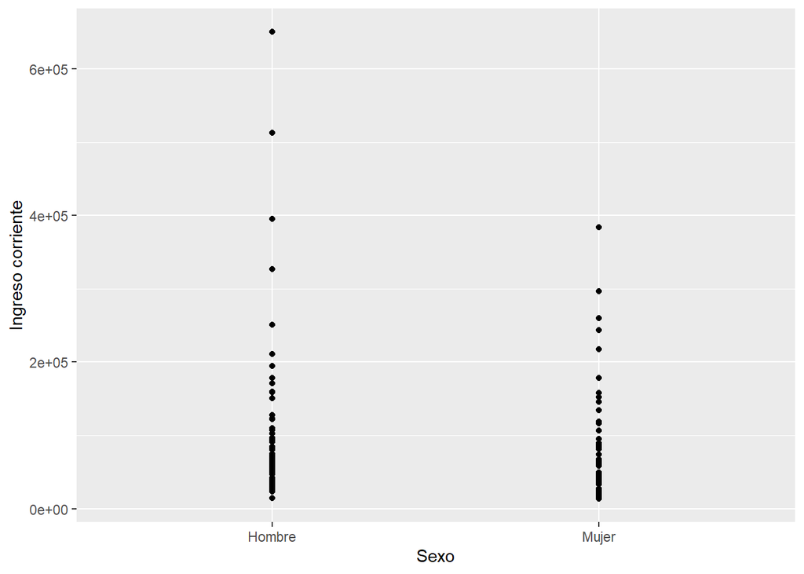

```r
ggplot(datos,aes(sexo_jefe, ing_cor))+geom_point() +labs(y= "Ingreso corriente", x = "Sexo")
```

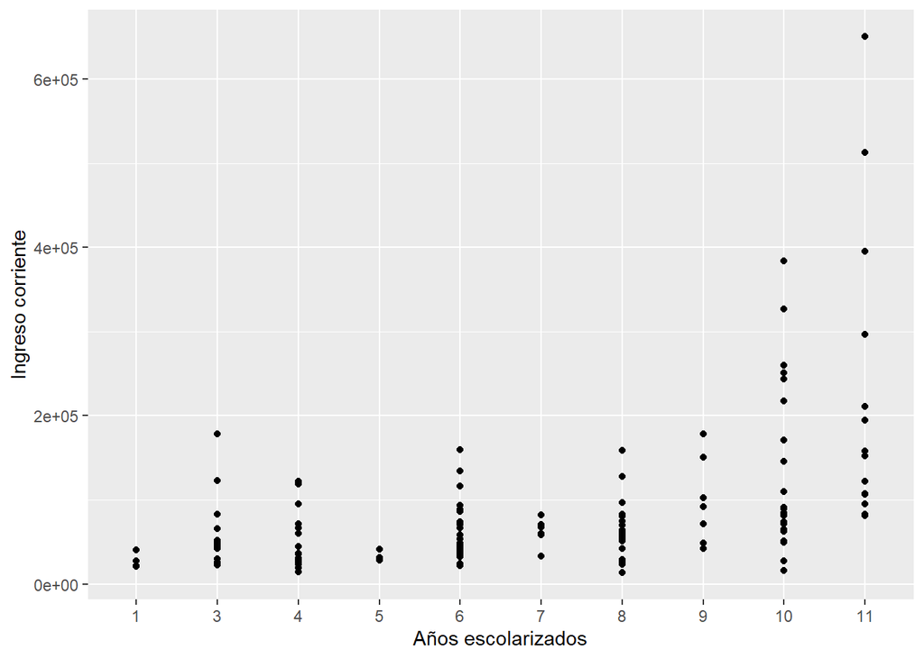

```r
ggplot(datos,aes(as.factor(educa_jefe), ing_cor))+geom_point() +labs(y= "Ingreso corriente", x = "Años escolarizados")
```

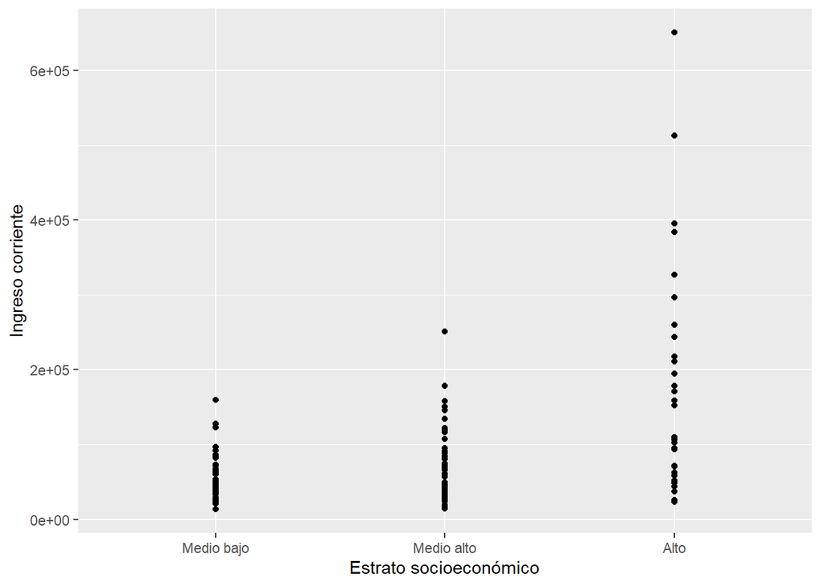

```r
ggplot(datos,aes(as.factor(est_socio), ing_cor))+geom_point() +labs(y= "Ingreso corriente", x = "Estrato socioeconómico")
```

ESTE ES EL MODELO CON EL QUE VAMOS A TRABAJAR

Tras reducir el modelo por dos variable; es decir, tras quitar el estrato socioeconómico y el sexo, el modelo mejorado queda como $Y = \beta_0 + \beta_1 X_{edad} + \beta_2 X_{erogac} + \beta_3 X_{gasto} + \beta_4 X_{añosEsc}$

```r
  mejoraCDMX <- lm(datos$ing_cor ~ edad_jefe  +erogac_tot + gasto_mon  + educa_jefe, datos)
  summary(mejoraCDMX)
```

```
##
## Call:
## lm(formula = datos$ing_cor ~ edad_jefe + erogac_tot + gasto_mon +
##     educa_jefe, data = datos)
##
## Residuals:
##     Min      1Q  Median      3Q     Max
## -101422  -21490   -3422   12654  354820
##
## Coefficients:
##               Estimate Std. Error t value Pr(>|t|)
## (Intercept) -7.445e+04  2.146e+04  -3.469 0.000696 ***
## edad_jefe    9.984e+02  2.720e+02   3.671 0.000344 ***
## erogac_tot   6.726e-01  2.286e-01   2.943 0.003814 **
## gasto_mon    1.228e+00  1.146e-01  10.716  < 2e-16 ***
## educa_jefe   6.390e+03  1.724e+03   3.706 0.000303 ***
## ---
## Signif. codes:  0 '***' 0.001 '**' 0.01 '*' 0.05 '.' 0.1 ' ' 1
##
## Residual standard error: 45170 on 139 degrees of freedom
## Multiple R-squared:  0.7576, Adjusted R-squared:  0.7506
## F-statistic: 108.6 on 4 and 139 DF,  p-value: < 2.2e-16
```

Para ver si hay **colinealidad** veamos si algunos de los eigenvalores de X’X son cercanos a 0

```r
  m <- datos
  m<- m[,-c(1,2,5,6,7)]
  m1 <- as.matrix(m)
  mat <- t(m1) %*% m1
  eigen(mat)
```

```
## eigen() decomposition
## $values
## [1] 6.959448e+11 4.078808e+10 2.215182e+05 1.545136e+03
##
## $vectors
##               [,1]          [,2]          [,3]          [,4]
## [1,] -5.229394e-04 -8.652720e-04  0.9967647763  8.036765e-02
## [2,] -8.139062e-05 -9.127762e-05  0.0803675654 -9.967653e-01
## [3,] -9.702304e-01 -2.421829e-01 -0.0007227301  4.312898e-05
## [4,] -2.421834e-01  9.702302e-01  0.0007160935 -1.133483e-05
```

Observemos que el eigenvalor más pequeño es 1545.136 $\neq$ 0, por lo que no se sugiere que haya colinealidad. Saquemos el número de condición de la matriz dado por $k=\frac{\lambda_{max}}{\lambda_{min}}$

```r
  eigen(mat)$values[1] / eigen(mat)$values[4]
```

```
## [1] 450410041
```

Para supuesto esperanza cero del error y NORMALIDAD DE LOS ERRORES:

```r
summary(mejoraCDMX)
```

```
##
## Call:
## lm(formula = datos$ing_cor ~ edad_jefe + erogac_tot + gasto_mon +
##     educa_jefe, data = datos)
##
## Residuals:
##     Min      1Q  Median      3Q     Max
## -101422  -21490   -3422   12654  354820
##
## Coefficients:
##               Estimate Std. Error t value Pr(>|t|)
## (Intercept) -7.445e+04  2.146e+04  -3.469 0.000696 ***
## edad_jefe    9.984e+02  2.720e+02   3.671 0.000344 ***
## erogac_tot   6.726e-01  2.286e-01   2.943 0.003814 **
## gasto_mon    1.228e+00  1.146e-01  10.716  < 2e-16 ***
## educa_jefe   6.390e+03  1.724e+03   3.706 0.000303 ***
## ---
## Signif. codes:  0 '***' 0.001 '**' 0.01 '*' 0.05 '.' 0.1 ' ' 1
##
## Residual standard error: 45170 on 139 degrees of freedom
## Multiple R-squared:  0.7576, Adjusted R-squared:  0.7506
## F-statistic: 108.6 on 4 and 139 DF,  p-value: < 2.2e-16
```

```r
media_error <- sum(mejoraCDMX$residuals)

S <-sqrt(sum(mejoraCDMX$residuals^2)/(144-5))
resi_est <- mejoraCDMX$residuals/S
#primero cargamos la base de datos sin los datos atipicos
BaseSA <- read.csv("BaseSA.csv")
sin_ati <- lm(BaseSA$ing_cor ~ edad_jefe  +erogac_tot + gasto_mon  + educa_jefe, BaseSA)
summary(sin_ati)
```

```
##
## Call:
## lm(formula = BaseSA$ing_cor ~ edad_jefe + erogac_tot + gasto_mon +
##     educa_jefe, data = BaseSA)
##
## Residuals:
##    Min     1Q Median     3Q    Max
## -46557 -16346   -922   9956  79463
##
## Coefficients:
##               Estimate Std. Error t value Pr(>|t|)
## (Intercept) -3.102e+04  1.126e+04  -2.755 0.006651 **
## edad_jefe    6.318e+02  1.427e+02   4.428 1.91e-05 ***
## erogac_tot   6.277e-01  1.199e-01   5.235 5.97e-07 ***
## gasto_mon    1.015e+00  6.014e-02  16.879  < 2e-16 ***
## educa_jefe   3.314e+03  9.045e+02   3.664 0.000352 ***
## ---
## Signif. codes:  0 '***' 0.001 '**' 0.01 '*' 0.05 '.' 0.1 ' ' 1
##
## Residual standard error: 23700 on 139 degrees of freedom
## Multiple R-squared:  0.8802, Adjusted R-squared:  0.8767
## F-statistic: 255.3 on 4 and 139 DF,  p-value: < 2.2e-16
```

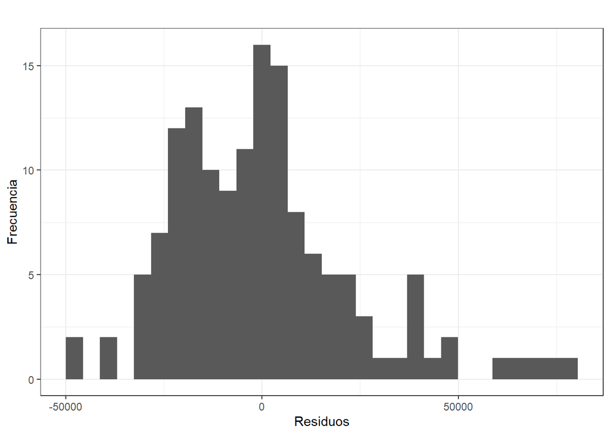

```r
ggplot(BaseSA, aes( x = sin_ati$residuals)) + labs(x = 'Residuos',y = 'Frecuencia', title = '') + geom_histogram() + theme_bw()
```

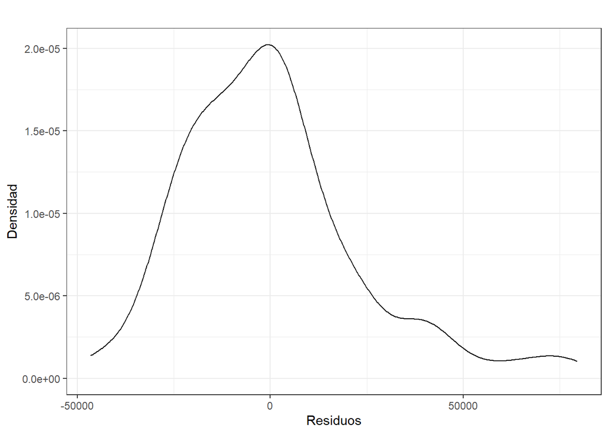

```r
ggplot(BaseSA,aes(sin_ati$residuals))+ labs(x = 'Residuos',y = 'Densidad', title = '') + geom_density() + theme_bw()
```

```r
jb.norm.test(sin_ati$residuals,nrepl=2000) #Use Jarque Bera porque ya incluye lo de asimetría y kurtosis
```

```
##
##  Jarque-Bera test for normality
##
## data:  sin_ati$residuals
## JB = 36.763, p-value = 5e-04
```

```r
#Se rechaza la hipótesis nula de que se distribuyen normal
```

Histograma con línea de modelo inicial

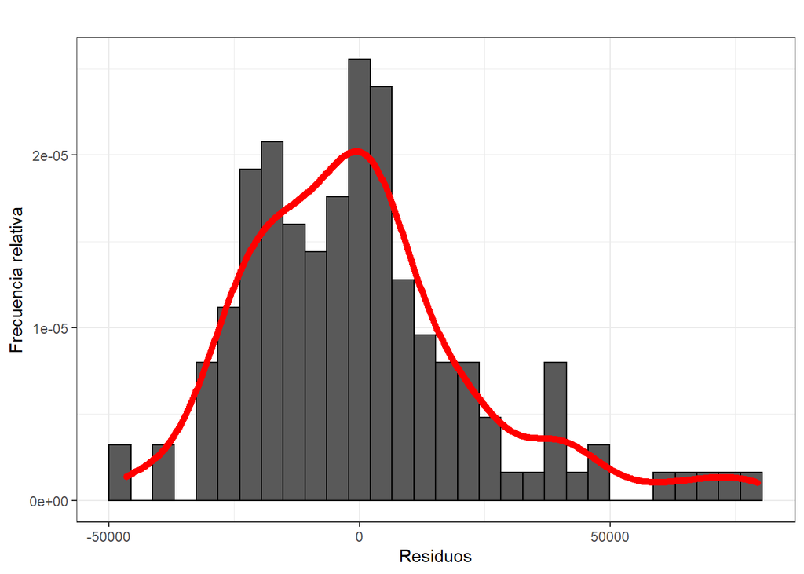

```r
  #primero cargamos la base de datos sin los datos atipicos
  BaseSA <- read.csv("BaseSA.csv")
  sin_ati <- lm(BaseSA$ing_cor ~ edad_jefe  +erogac_tot + gasto_mon  + educa_jefe, BaseSA)

  X <- sin_ati$residuals
  df <- data.frame(X)
  histog <- ggplot(data = df, aes(x=X)) + geom_histogram(aes(y=..density..), color = "black") + theme_bw() + geom_density(kernel="gaussian", color = "red", size=2) + labs(x = 'Residuos',y = 'Frecuencia relativa', title = '')
  histog
```

TRANSFORMACION POTENCIA

```r
transf <- lm(ing_cor^(1/2) ~ edad_jefe  + erogac_tot + gasto_mon  + educa_jefe, BaseSA)
summary(transf)
```

```
##
## Call:
## lm(formula = ing_cor^(1/2) ~ edad_jefe + erogac_tot + gasto_mon +
##     educa_jefe, data = BaseSA)
##
## Residuals:
##      Min       1Q   Median       3Q      Max
## -138.488  -32.206   -3.104   26.991  142.291
##
## Coefficients:
##              Estimate Std. Error t value Pr(>|t|)
## (Intercept) 6.657e+01  2.294e+01   2.901  0.00432 **
## edad_jefe   1.232e+00  2.907e-01   4.238 4.09e-05 ***
## erogac_tot  6.168e-04  2.443e-04   2.525  0.01271 *
## gasto_mon   1.321e-03  1.225e-04  10.776  < 2e-16 ***
## educa_jefe  9.099e+00  1.843e+00   4.937 2.24e-06 ***
## ---
## Signif. codes:  0 '***' 0.001 '**' 0.01 '*' 0.05 '.' 0.1 ' ' 1
##
## Residual standard error: 48.29 on 139 degrees of freedom
## Multiple R-squared:  0.7672, Adjusted R-squared:  0.7605
## F-statistic: 114.5 on 4 and 139 DF,  p-value: < 2.2e-16
```

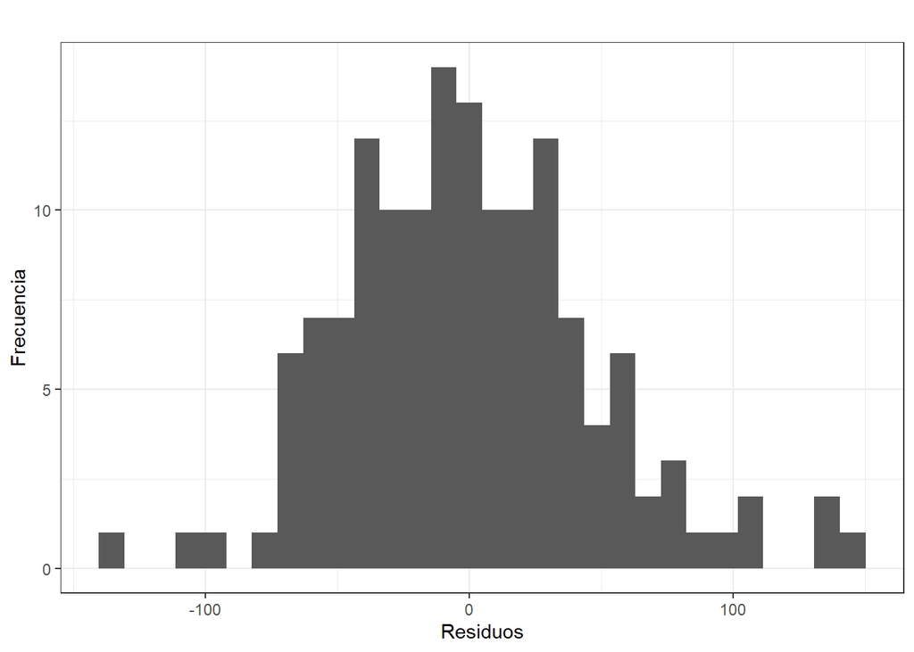

```r
St<-sqrt(sum(transf$residuals^2)/139)
ggplot(BaseSA, aes( x = transf$residuals)) + labs(x = 'Residuos',y = 'Frecuencia', title = '') + geom_histogram() + theme_bw()
```

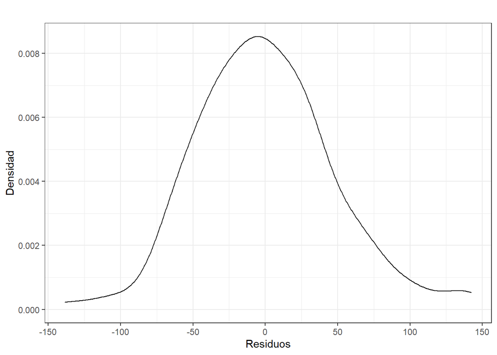

```r
ggplot(BaseSA,aes(transf$residuals))+ labs(x = 'Residuos',y = 'Densidad', title = '') + geom_density() + theme_bw()
```

```r
jb.norm.test(transf$residuals,nrepl=2000)
```

```
##
##  Jarque-Bera test for normality
##
## data:  transf$residuals
## JB = 5.6932, p-value = 0.0515
```

```r
#comparamos con
qchisq(.95,2)
```

```
## [1] 5.991465
```

```r
#No se rechaza la hipotesis nula de que se distribuyen normal
```

Histograma con densidad de transformación potencia

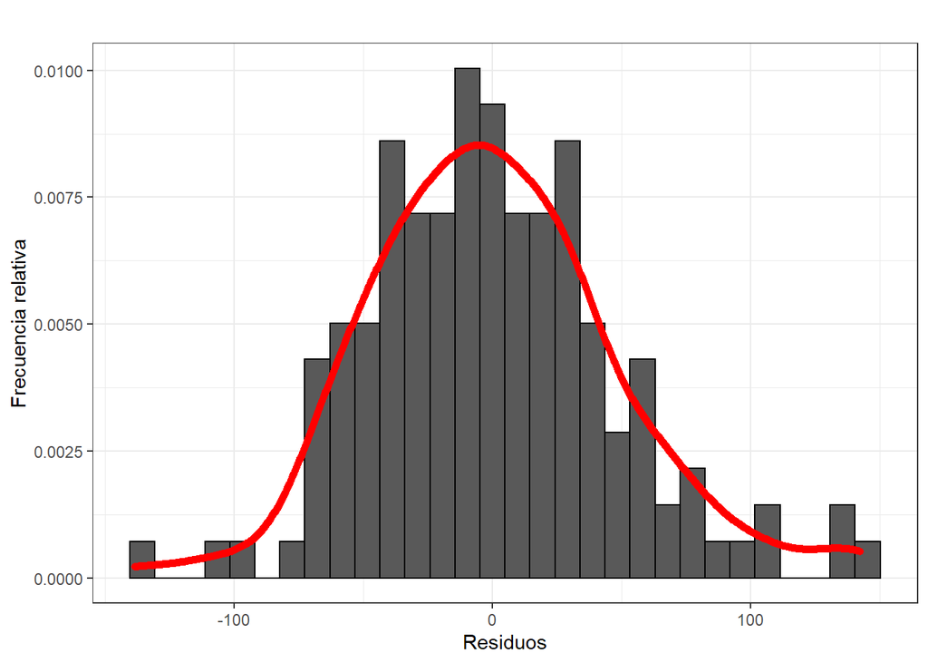

```r
  transf <- lm(ing_cor^(1/2) ~ edad_jefe  + erogac_tot + gasto_mon  + educa_jefe, BaseSA)

  X <- transf$residuals
  df <- data.frame(X)
  histog <- ggplot(data = df, aes(x=X)) + geom_histogram(aes(y=..density..), color = "black") + theme_bw() + geom_density(kernel="gaussian", color = "red", size=2) + labs(x = 'Residuos',y = 'Frecuencia relativa', title = '')
  histog
```

HETEROSCEDASTICIDAD

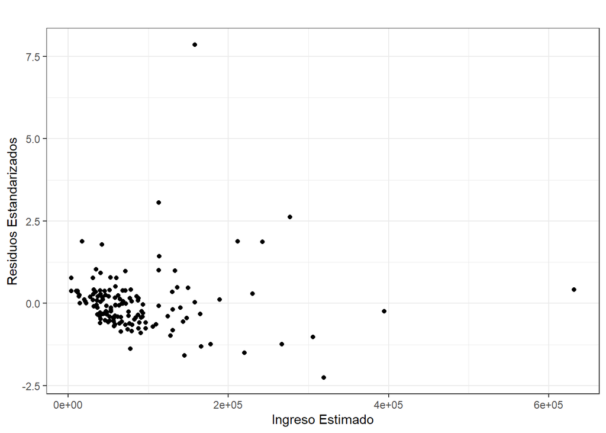

```r
#primero analizamos la siguiente grafica modelo solo con orcutt
ggplot(datos, aes(x = mejoraCDMX$fitted.values ,y =mejoraCDMX$residuals/S)) +
  labs(x = 'Ingreso Estimado',y = 'Residuos Estandarizados', title = '') + geom_point() + theme_bw()
```

```r
#Vemos cómo que los residuos siguen un patron
#Regresión Auxiliar
aux <- lm(mejoraCDMX$residuals^2 ~ edad_jefe  + erogac_tot + gasto_mon  + educa_jefe + edad_jefe^2  + erogac_tot^2 + gasto_mon^2  + educa_jefe^2 + edad_jefe*erogac_tot + edad_jefe*gasto_mon  + edad_jefe*educa_jefe + erogac_tot*gasto_mon  + erogac_tot*educa_jefe + gasto_mon*educa_jefe, datos)
summary(aux)
```

```
##
## Call:
## lm(formula = mejoraCDMX$residuals^2 ~ edad_jefe + erogac_tot +
##     gasto_mon + educa_jefe + edad_jefe^2 + erogac_tot^2 + gasto_mon^2 +
##     educa_jefe^2 + edad_jefe * erogac_tot + edad_jefe * gasto_mon +
##     edad_jefe * educa_jefe + erogac_tot * gasto_mon + erogac_tot *
##     educa_jefe + gasto_mon * educa_jefe, data = datos)
##
## Residuals:
##        Min         1Q     Median         3Q        Max
## -1.281e+10 -1.774e+09 -6.362e+08  2.529e+08  1.176e+11
##
## Coefficients:
##                         Estimate Std. Error t value Pr(>|t|)
## (Intercept)            5.084e+09  1.156e+10   0.440    0.661
## edad_jefe             -7.300e+07  1.672e+08  -0.437    0.663
## erogac_tot            -7.440e+04  5.148e+05  -0.145    0.885
## gasto_mon             -2.815e+05  2.458e+05  -1.145    0.254
## educa_jefe            -1.993e+08  1.611e+09  -0.124    0.902
## edad_jefe:erogac_tot   2.113e+02  5.052e+03   0.042    0.967
## edad_jefe:gasto_mon    2.854e+03  3.193e+03   0.894    0.373
## edad_jefe:educa_jefe   6.261e+06  2.669e+07   0.235    0.815
## erogac_tot:gasto_mon  -6.356e-01  4.305e-01  -1.476    0.142
## erogac_tot:educa_jefe  1.503e+04  3.822e+04   0.393    0.695
## gasto_mon:educa_jefe   1.630e+04  1.348e+04   1.209    0.229
##
## Residual standard error: 1.065e+10 on 133 degrees of freedom
## Multiple R-squared:  0.07631,    Adjusted R-squared:  0.006855
## F-statistic: 1.099 on 10 and 133 DF,  p-value: 0.3677
```

```r
nr2 <- 144*0.07631
nr2
```

```
## [1] 10.98864
```

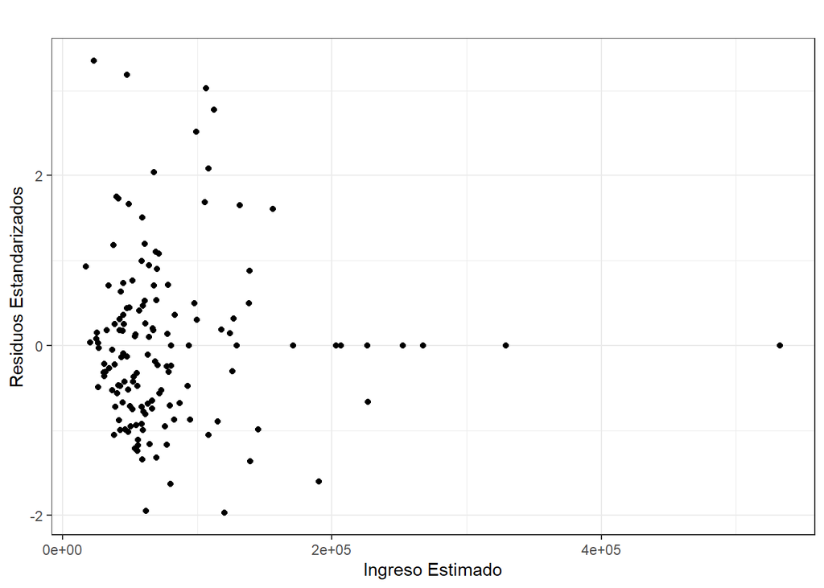

```r
#analizando sin datos atipicos
Sta<-sqrt(sum(sin_ati$residuals^2)/139)
ggplot(BaseSA, aes(x = sin_ati$fitted.values ,y =sin_ati$residuals/Sta)) +
  labs(x = 'Ingreso Estimado',y = 'Residuos Estandarizados', title = '') + geom_point() + theme_bw()
```

```r
aux2 <- lm(sin_ati$residuals^2 ~ edad_jefe  + erogac_tot + gasto_mon  + educa_jefe + edad_jefe^2  + erogac_tot^2 + gasto_mon^2  + educa_jefe^2 + edad_jefe*erogac_tot + edad_jefe*gasto_mon  + edad_jefe*educa_jefe + erogac_tot*gasto_mon  + erogac_tot*educa_jefe + gasto_mon*educa_jefe, BaseSA)
summary(aux2)
```

```
##
## Call:
## lm(formula = sin_ati$residuals^2 ~ edad_jefe + erogac_tot + gasto_mon +
##     educa_jefe + edad_jefe^2 + erogac_tot^2 + gasto_mon^2 + educa_jefe^2 +
##     edad_jefe * erogac_tot + edad_jefe * gasto_mon + edad_jefe *
##     educa_jefe + erogac_tot * gasto_mon + erogac_tot * educa_jefe +
##     gasto_mon * educa_jefe, data = BaseSA)
##
## Residuals:
##        Min         1Q     Median         3Q        Max
## -1.631e+09 -4.732e+08 -2.487e+08  4.866e+07  5.318e+09
##
## Coefficients:
##                         Estimate Std. Error t value Pr(>|t|)
## (Intercept)           -8.760e+08  1.097e+09  -0.799   0.4260
## edad_jefe              8.940e+06  1.586e+07   0.564   0.5738
## erogac_tot             1.082e+03  4.883e+04   0.022   0.9824
## gasto_mon             -9.669e+02  2.332e+04  -0.041   0.9670
## educa_jefe             3.089e+08  1.528e+08   2.022   0.0452 *
## edad_jefe:erogac_tot   3.407e+01  4.792e+02   0.071   0.9434
## edad_jefe:gasto_mon    3.630e+02  3.029e+02   1.199   0.2328
## edad_jefe:educa_jefe  -3.486e+06  2.531e+06  -1.377   0.1707
## erogac_tot:gasto_mon   1.997e-03  4.083e-02   0.049   0.9611
## erogac_tot:educa_jefe  3.399e+02  3.625e+03   0.094   0.9254
## gasto_mon:educa_jefe  -2.269e+03  1.278e+03  -1.775   0.0782 .
## ---
## Signif. codes:  0 '***' 0.001 '**' 0.01 '*' 0.05 '.' 0.1 ' ' 1
##
## Residual standard error: 1.01e+09 on 133 degrees of freedom
## Multiple R-squared:  0.06803,    Adjusted R-squared:  -0.002043
## F-statistic: 0.9708 on 10 and 133 DF,  p-value: 0.4719
```

```r
nr22 <-144*0.06803
nr22
```

```
## [1] 9.79632
```

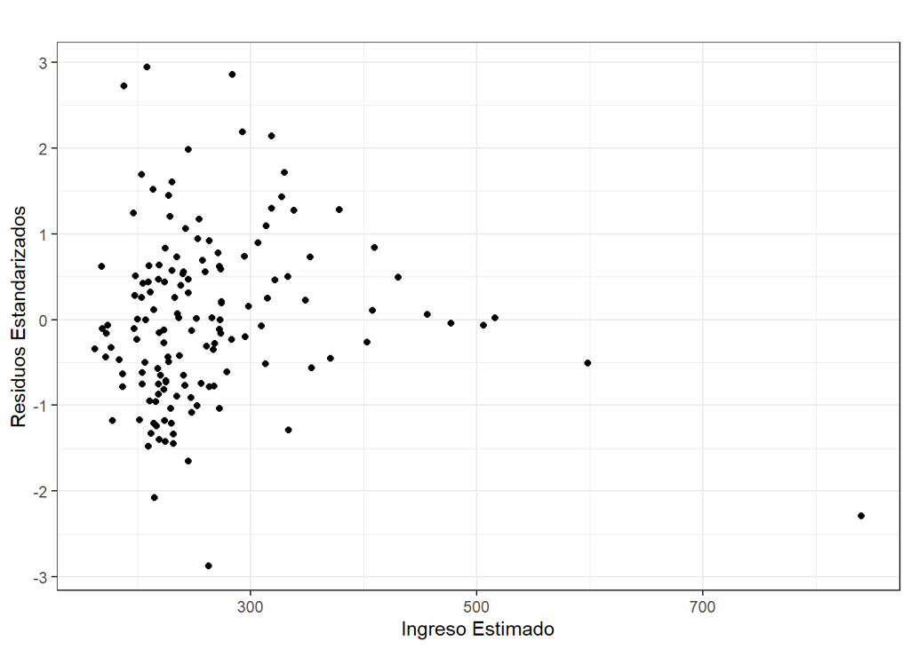

```r
#Analizando heterosc con la transformcion potencia
ggplot(BaseSA, aes(x = transf$fitted.values ,y =transf$residuals/St)) +
  labs(x = 'Ingreso Estimado',y = 'Residuos Estandarizados', title = '') + geom_point() + theme_bw()
```

```r
#prueba de white
#Regresión Auxiliar
aux3 <- lm(transf$residuals^2 ~ edad_jefe  + erogac_tot + gasto_mon  + educa_jefe + edad_jefe^2  + erogac_tot^2 + gasto_mon^2  + educa_jefe^2 + edad_jefe*erogac_tot + edad_jefe*gasto_mon  + edad_jefe*educa_jefe + erogac_tot*gasto_mon  + erogac_tot*educa_jefe + gasto_mon*educa_jefe, BaseSA)
summary(aux3)
```

```
##
## Call:
## lm(formula = transf$residuals^2 ~ edad_jefe + erogac_tot + gasto_mon +
##     educa_jefe + edad_jefe^2 + erogac_tot^2 + gasto_mon^2 + educa_jefe^2 +
##     edad_jefe * erogac_tot + edad_jefe * gasto_mon + edad_jefe *
##     educa_jefe + erogac_tot * gasto_mon + erogac_tot * educa_jefe +
##     gasto_mon * educa_jefe, data = BaseSA)
##
## Residuals:
##     Min      1Q  Median      3Q     Max
## -5345.2 -1901.7  -888.4   535.4 18514.8
##
## Coefficients:
##                         Estimate Std. Error t value Pr(>|t|)
## (Intercept)           -3.417e+03  3.872e+03  -0.882  0.37914
## edad_jefe              4.669e+01  5.597e+01   0.834  0.40566
## erogac_tot             1.273e-01  1.724e-01   0.739  0.46143
## gasto_mon              1.433e-02  8.230e-02   0.174  0.86205
## educa_jefe             9.735e+02  5.394e+02   1.805  0.07340 .
## edad_jefe:erogac_tot  -1.971e-04  1.692e-03  -0.117  0.90740
## edad_jefe:gasto_mon    7.289e-04  1.069e-03   0.682  0.49658
## edad_jefe:educa_jefe  -9.140e+00  8.935e+00  -1.023  0.30816
## erogac_tot:gasto_mon   4.453e-07  1.441e-07   3.090  0.00244 **
## erogac_tot:educa_jefe -1.482e-02  1.280e-02  -1.158  0.24892
## gasto_mon:educa_jefe  -8.138e-03  4.512e-03  -1.803  0.07359 .
## ---
## Signif. codes:  0 '***' 0.001 '**' 0.01 '*' 0.05 '.' 0.1 ' ' 1
##
## Residual standard error: 3566 on 133 degrees of freedom
## Multiple R-squared:  0.1247, Adjusted R-squared:  0.05888
## F-statistic: 1.895 on 10 and 133 DF,  p-value: 0.05111
```

```r
#El estadistico de prueba es
nr23 <- 144*0.1247
nr23
```

```
## [1] 17.9568
```

```r
qchisq(.95, 14)
```

```
## [1] 23.68479
```

```r
#No se rechaza la hipótesis Ho, los residuos son homoscedasticos
```